# Distance sampling

Jez Bird

26 March 2019

## Cleaning raw detection data

Set working directory

```r
knitr::opts_knit$set(root.dir = normalizePath("C:/Users/Jez/Documents/PhD/Analysis/Data/Island-wide"))
```

Read in raw transect data - this contains all detections along transects. Transects have not been split into sections yet.

```r
raw_transect_data <- read.csv("Raw_transect_data.csv")

summary(raw_transect_data)
```

```
##     Transect          Start           End            Waypoint
##  Min.   :  1.00   Min.   : 288   Min.   : 289.0   Min.   :   1.0
##  1st Qu.: 76.25   1st Qu.: 368   1st Qu.: 366.0   1st Qu.: 426.0
##  Median :114.00   Median : 514   Median : 510.0   Median : 880.0
##  Mean   :108.62   Mean   : 930   Mean   : 917.3   Mean   : 912.1
##  3rd Qu.:144.00   3rd Qu.:1802   3rd Qu.:1750.0   3rd Qu.:1349.8
##  Max.   :218.00   Max.   :1992   Max.   :1993.0   Max.   :2000.0
##                   NA's   :1      NA's   :55       NA's   :120
##       lat              lon             ele
##  Min.   :-54.77   Min.   :158.8   Min.   : 13.25
##  1st Qu.:-54.71   1st Qu.:158.8   1st Qu.:178.82
##  Median :-54.66   Median :158.8   Median :220.49
##  Mean   :-54.66   Mean   :158.9   Mean   :217.62
##  3rd Qu.:-54.61   3rd Qu.:158.9   3rd Qu.:256.01
##  Max.   :-54.49   Max.   :158.9   Max.   :396.17
##  NA's   :123      NA's   :123     NA's   :123
##                    time         Species     Mark        Distance
##                      : 123   AP     :2848    : 120   Min.   : 0.000
##  2018-01-05T02:57:12Z:   1   WHP    : 306   B:3051   1st Qu.: 0.800
##  2018-01-05T03:00:46Z:   1          : 120   P: 195   Median : 1.600
##  2018-01-05T03:06:42Z:   1   SPP?   :  55            Mean   : 2.328
##  2018-01-05T03:09:06Z:   1   UNK    :  15            3rd Qu.: 3.100
##  2018-01-05T03:10:02Z:   1   WHP?   :  13            Max.   :40.000
##  (Other)             :3238   (Other):   9            NA's   :121
##  Slope       Puff.age     Veg.height Feather.sample
##   : 120   Min.   :1.000   0: 617            :3342
##  D:1246   1st Qu.:2.000   S:2696     F?     :   1
##  F: 552   Median :3.000   T:  53     F01    :   1
##  U:1448   Mean   :2.626              F02    :   1
##           3rd Qu.:3.000              F03    :   1
##           Max.   :4.000              F04    :   1
##           NA's   :3187               (Other):  19
##               Poo.sample   Observer
##                    :3349   JB:2126
##  3                 :   1   PP:1240
##  4                 :   1
##  POO 324           :   1
##  POO 353 VEG/RECENT:   1
##  POO327 DIRT/DRY   :   1
##  (Other)           :  12
```

```r
colnames(raw_transect_data)
```

```
##  [1] "Transect"       "Start"          "End"            "Waypoint"
##  [5] "lat"            "lon"            "ele"            "time"
##  [9] "Species"        "Mark"           "Distance"       "Slope"
## [13] "Puff.age"       "Veg.height"     "Feather.sample" "Poo.sample"
## [17] "Observer"
```

Tidy the data

```r
library(dplyr)
## Rename columns
raw_transect_data = rename(raw_transect_data, veg_height = `Veg.height`)
raw_transect_data = rename(raw_transect_data, puff_age = `Puff.age`)

## Delete columns
raw_transect_data$Feather.sample <- NULL
raw_transect_data$Poo.sample <- NULL

saveRDS(raw_transect_data, "Transect_data_renamed.Rds")

transect_data_renamed = readRDS("Transect_data_renamed.Rds")

sapply(transect_data_renamed, class)
```

```
##   Transect      Start        End   Waypoint        lat        lon
##  "integer"  "integer"  "integer"  "integer"  "numeric"  "numeric"
##        ele       time    Species       Mark   Distance      Slope
##  "numeric"   "factor"   "factor"   "factor"  "numeric"   "factor"
##   puff_age veg_height   Observer
##  "integer"   "factor"   "factor"
```

```r
transect_data_renamed[["puff_age"]] = as.factor(transect_data_renamed[["puff_age"]])

# reset missing veg_height values as NA
missing_veg_height <- transect_data_renamed[["veg_height"]] == 0

transect_data_renamed[["veg_height"]][missing_veg_height] <- NA

summary(transect_data_renamed)
```

```
##     Transect          Start           End            Waypoint
##  Min.   :  1.00   Min.   : 288   Min.   : 289.0   Min.   :   1.0
##  1st Qu.: 76.25   1st Qu.: 368   1st Qu.: 366.0   1st Qu.: 426.0
##  Median :114.00   Median : 514   Median : 510.0   Median : 880.0
##  Mean   :108.62   Mean   : 930   Mean   : 917.3   Mean   : 912.1
##  3rd Qu.:144.00   3rd Qu.:1802   3rd Qu.:1750.0   3rd Qu.:1349.8
##  Max.   :218.00   Max.   :1992   Max.   :1993.0   Max.   :2000.0
##                   NA's   :1      NA's   :55       NA's   :120
##       lat              lon             ele
##  Min.   :-54.77   Min.   :158.8   Min.   : 13.25
##  1st Qu.:-54.71   1st Qu.:158.8   1st Qu.:178.82
##  Median :-54.66   Median :158.8   Median :220.49
##  Mean   :-54.66   Mean   :158.9   Mean   :217.62
##  3rd Qu.:-54.61   3rd Qu.:158.9   3rd Qu.:256.01
##  Max.   :-54.49   Max.   :158.9   Max.   :396.17
##  NA's   :123      NA's   :123     NA's   :123
##                    time         Species     Mark        Distance
##                      : 123   AP     :2848    : 120   Min.   : 0.000
##  2018-01-05T02:57:12Z:   1   WHP    : 306   B:3051   1st Qu.: 0.800
##  2018-01-05T03:00:46Z:   1          : 120   P: 195   Median : 1.600
##  2018-01-05T03:06:42Z:   1   SPP?   :  55            Mean   : 2.328
##  2018-01-05T03:09:06Z:   1   UNK    :  15            3rd Qu.: 3.100
##  2018-01-05T03:10:02Z:   1   WHP?   :  13            Max.   :40.000
##  (Other)             :3238   (Other):   9            NA's   :121
##  Slope    puff_age    veg_height  Observer
##   : 120   1   :  27   0   :   0   JB:2126
##  D:1246   2   :  57   S   :2696   PP:1240
##  F: 552   3   :  51   T   :  53
##  U:1448   4   :  44   NA's: 617
##           NA's:3187
##
##
```

```r
library(ggplot2)
library(gridExtra)
## Split the data by species and sign (burrow or puff)

library(data.table)
setDT(transect_data_renamed)

prion_brws <- transect_data_renamed[Species == "AP" & Mark == "B",]
prion_puffs <- transect_data_renamed[Species == "AP" & Mark == "P",]
WHP_brws <- transect_data_renamed[Species == "WHP" & Mark == "B",]

saveRDS(prion_brws, "prion_brws.Rds")
prion_brws = readRDS("prion_brws.Rds")

saveRDS(prion_puffs, "prion_puffs.Rds")
prion_puffs = readRDS("prion_puffs.Rds")

saveRDS(WHP_brws, "WHP_brws.Rds")
WHP_brws = readRDS("WHP_brws.Rds")
```

Explore the influence of observer, slope, veg height on distance data

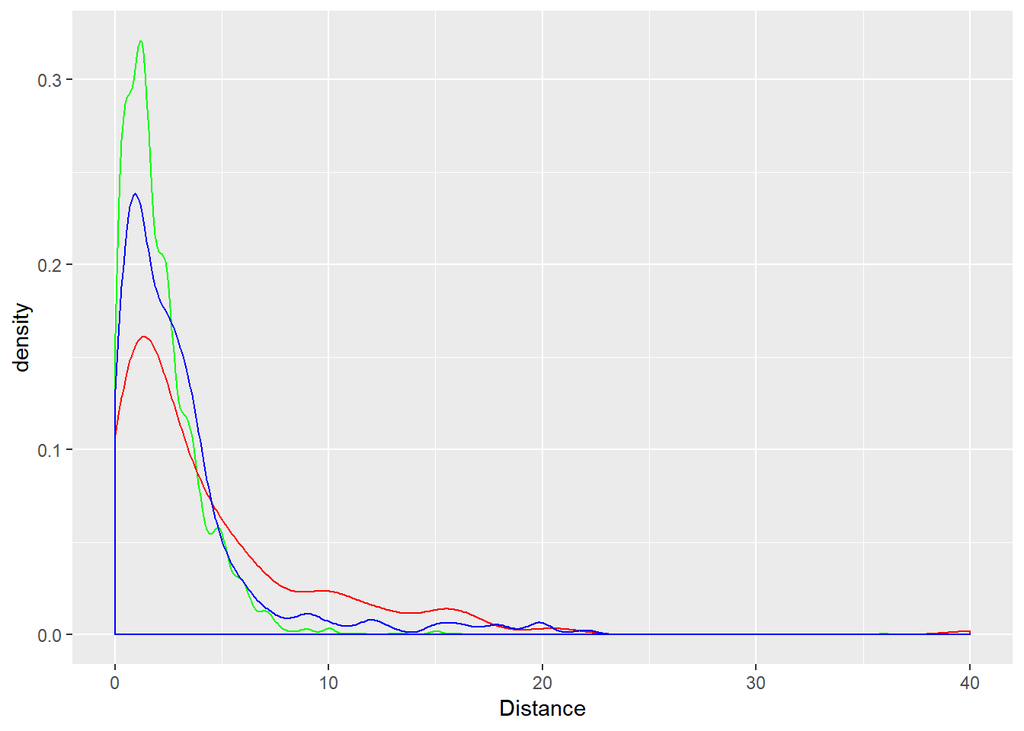

```r
All_sp_plot <- ggplot() +
  geom_density(data=prion_brws, aes(x=Distance), color='green') +
  geom_density(data = prion_puffs, aes(x=Distance), color='red') +
  geom_density(data = WHP_brws, aes(x=Distance), color='blue')
All_sp_plot
```

Prion puffs were detected at greater distances than burrows, and White-headed Petrel burrows were detected at greater distances than Antarctic Prion burrows

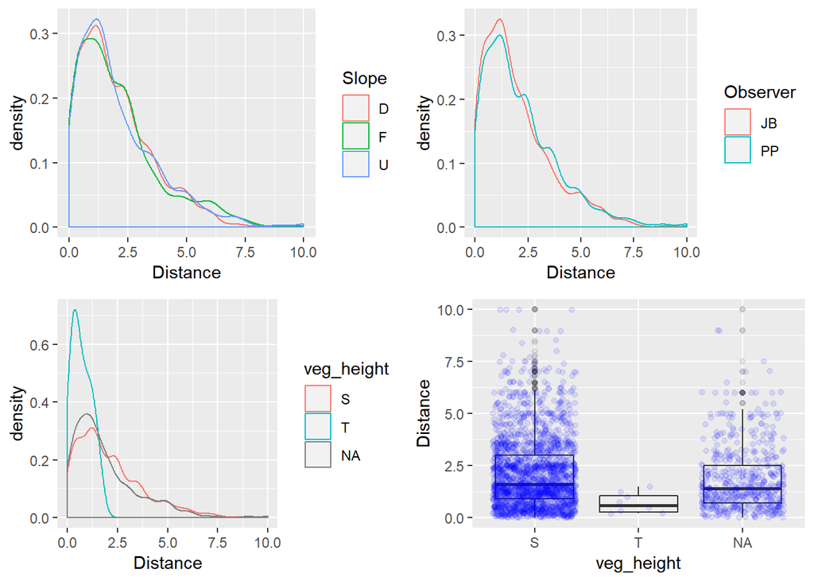

```r
AP_brw_slope_plot <- ggplot(data = prion_brws, aes(x=Distance, color=Slope)) + geom_density() + xlim(0,10)

AP_brw_observer_plot <- ggplot(data = prion_brws, aes(x=Distance, color=Observer)) + geom_density() + xlim(0,10)

AP_brw_veg_height_density_plot <- ggplot(data = prion_brws, aes(x=Distance, color=veg_height)) + geom_density() + xlim(0,10)

AP_brw_veg_height_box_plot <- ggplot(data = prion_brws, aes(x=veg_height, y=Distance)) + geom_boxplot(alpha=0.1) +geom_jitter(alpha = 0.1, color = "blue") + ylim(0,10)

grid.arrange(AP_brw_slope_plot, AP_brw_observer_plot, AP_brw_veg_height_density_plot, AP_brw_veg_height_box_plot, nrow = 2)
```

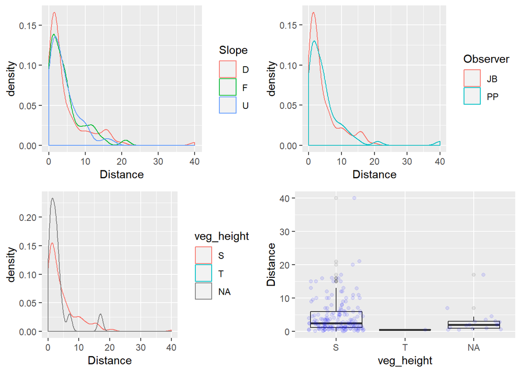

```r
AP_puff_slope_plot <- ggplot(data = prion_puffs, aes(x=Distance, color=Slope)) + geom_density() + xlim(0,40)

AP_puff_observer_plot <- ggplot(data = prion_puffs, aes(x=Distance, color=Observer)) + geom_density() + xlim(0,40)

AP_puff_veg_height_density_plot <- ggplot(data = prion_puffs, aes(x=Distance, color=veg_height)) + geom_density() + xlim(0,40)

AP_puff_veg_height_box_plot <- ggplot(data = prion_puffs, aes(x=veg_height, y=Distance)) + geom_boxplot(alpha=0.1) +geom_jitter(alpha = 0.1, color = "blue") + ylim(0,40)

grid.arrange(AP_puff_slope_plot, AP_puff_observer_plot, AP_puff_veg_height_density_plot, AP_puff_veg_height_box_plot, nrow = 2)
```

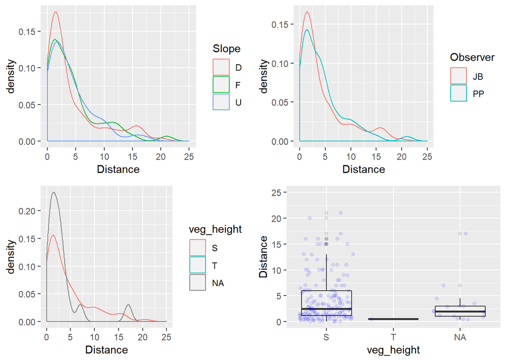

```r
WHP_brw_slope_plot <- ggplot(data = prion_puffs, aes(x=Distance, color=Slope)) + geom_density() + xlim(0,25)

WHP_brw_observer_plot <- ggplot(data = prion_puffs, aes(x=Distance, color=Observer)) + geom_density() + xlim(0,25)

WHP_brw_veg_height_density_plot <- ggplot(data = prion_puffs, aes(x=Distance, color=veg_height)) + geom_density() + xlim(0,25)

WHP_brw_veg_height_box_plot <- ggplot(data = prion_puffs, aes(x=veg_height, y=Distance)) + geom_boxplot(alpha=0.1) +geom_jitter(alpha = 0.1, color = "blue") + ylim(0,25)

grid.arrange(WHP_brw_slope_plot, WHP_brw_observer_plot, WHP_brw_veg_height_density_plot, WHP_brw_veg_height_box_plot, nrow = 2)
```

Observer and slope don’t appear to have much of an influence on detection distance so will perhaps be of limited importance when modelling detection functions. Veg height does seem to be important although there were too few records of puffs or White-headed Petrel burrows, and perhaps even prion burrows in tall veg to draw conclusions.

## Distance analysis

The value of distance sampling and analysis over plot sampling is allowing for abundance estimation despite imperfect detection. Distance analysis delivers model robustness, meaning that unbiased estimates are still obtained even if not all sources of variability in detection are incorporated. Hence, it is not common to fit an exhaustive candidate model set to data, but there are approaches to capture covariates that may generate models that fit the data better. So, I explore different covariates below.

Distance analysis generally uses one of four main functions to describe the drop off in detection with distance from the transect:

1. Uniform - effectively no drop off in detection. Unrealistic but works with an adjustment term (see below)
2. Half-normal - half a Gaussian curve. The formula has one parameter that allows for changing scale (the drop-off can be steeper or shallower) but it’s not robust to changing shape - it’s always a Gaussian curve
3. Hazard-rate - has both scale and shape parameters so is more robust
4. Negative exponential - assumes detection starts dropping off immediately and then tails off with distance. Also unrealistic so not used here.

Cosine, Hermite and Polynomial adjustment terms can be fitted to change the shape of each key function e.g. a uniform function with a cosine adjustment becomes an S-shaped curve. It is not recommended to apply adjustments when covariates are being used in the model (although I don’t really understand why not).

## Covariates

Our data include a number of covariates that may influence detection probability:

- Observer (transect level data)
- Veg height (transect level data)
- Slope (observation lelevl data - up, down or flat)

In addition we want to assess the influence of stratum - both on detection probability and on density. We’re unable to fully stratify our analysis by splitting the data into strata because several strata had too few detections to allow a detection function to be fitted. Therefore, stratum can be used as a covariate to see if it improved model fit.

```r
knitr::opts_knit$set(root.dir = normalizePath("C:/Users/Jez/Documents/PhD/Data/Island-wide survey/R"))
library(Distance)
library(dsm)
library(mads)
library(tidyverse)
library(forcats)
library(knitr)
library(kableExtra)
## Set working directory
setwd(dir = "C:/Users/Jez/Documents/PhD/Data/Island-wide survey/R")

prions <- read.csv("AP_brws_multicov.csv")
head(prions)
```

```
##   Sample.Label Region.Label     Area Brw_number     Effort distance size
## 1         2515            5 16.64778          1 0.03361597   0.0003    1
## 2         2515            5 16.64778          2 0.03361597   0.0005    1
## 3         2515            5 16.64778          3 0.03361597   0.0003    1
## 4         2517            5 16.64778          4 0.08733898   0.0014    1
## 5         2515            5 16.64778          5 0.03361597   0.0035    1
## 6         2517            5 16.64778          6 0.08733898   0.0012    1
##   slope veg_height surveyor
## 1     D          S       PP
## 2     D          S       PP
## 3     D          S       PP
## 4     D          S       PP
## 5     D          S       PP
## 6     D          S       PP
```

```r
## First, using the pooled data test different models and adjustments to select the best fit (lowest AIC)

##key key function to use; "hn" gives half-normal (default), "hr" gives hazard-rate and
##"unif" gives uniform. Note that if uniform key is used, covariates cannot be
##included in the model.
##adjustment adjustment terms to use; "cos" gives cosine (default), "herm" gives Hermite
##polynomial and "poly" gives simple polynomial. "cos" is recommended. A
##value of NULL indicates that no adjustments are to be ???tted.

## Models to test:
## Half-normal
## Hazard-rate
## Half-normal + Cosine
## Hazard-rate + Cosine
## Uniform + Cosine
## Half-normal + Hermite
## Hazard-rate + Hermite
## Uniform + Hermite
## Half-normal + Polynomial
## Hazard-rate + Polynomial
## Uniform + Polynomial
## Half-normal + Stratum
## Hazard-rate + Stratum
## Half-normal + Observer
## Hazard-rate + Observer
## Half-normal + Veg height
## Hazard-rate + Veg height
## Half-normal + Stratum + Observer
## Hazard-rate + Stratum + Observer
## Half-normal + Stratum + Veg height
## Hazard-rate + Stratum + Veg height
## Half-normal + Observer + Veg height
## Hazard-rate + Observer + Veg height
## Half-normal + Stratum + Observer + Veg height
## Hazard-rate + Stratum + Observer + Veg height

prion.trunc <- "5%"
prion.half.norm <- ds(prions, truncation=prion.trunc,
                           key="hn",  adjustment=NULL)
```

```
## Fitting half-normal key function
```

```
## Key only model: not constraining for monotonicity.
```

```
## AIC= -26699.044
```

```r
prion.haz.rate <- ds(prions, truncation=prion.trunc,
                      key="hr",  adjustment=NULL)
```

```
## Fitting hazard-rate key function
```

```
## Key only model: not constraining for monotonicity.
```

```
## AIC= -26725.072
```

```r
prion.half.norm.cos <- ds(prions, truncation=prion.trunc,
                      key="hn",  adjustment="cos")
```

```
## Starting AIC adjustment term selection.
```

```
## Fitting half-normal key function
```

```
## Key only model: not constraining for monotonicity.
```

```
## AIC= -26699.044
```

```
## Fitting half-normal key function with cosine(2) adjustments
```

```
## AIC= -26706.278
```

```
## Fitting half-normal key function with cosine(2,3) adjustments
```

```
## AIC= -26715.145
```

```
## Fitting half-normal key function with cosine(2,3,4) adjustments
```

```
## AIC= -26713.247
```

```
##
## Half-normal key function with cosine(2,3) adjustments selected.
```

```r
prion.haz.rate.cos <- ds(prions, truncation=prion.trunc,
                     key="hr",  adjustment="cos")
```

```
## Starting AIC adjustment term selection.
```

```
## Fitting hazard-rate key function
```

```
## Key only model: not constraining for monotonicity.
```

```
## AIC= -26725.072
```

```
## Fitting hazard-rate key function with cosine(2) adjustments
```

```
## AIC= -26723.062
```

```
##
## Hazard-rate key function selected.
```

```r
prion.unif.cos <- ds(prions, truncation=prion.trunc,
                 key="unif",  adjustment="cos")
```

```
## Starting AIC adjustment term selection.
```

```
## Fitting uniform key function with cosine(1) adjustments
```

```
## AIC= -26706.574
```

```
## Fitting uniform key function with cosine(1,2) adjustments
```

```
## AIC= -26721.919
```

```
## Fitting uniform key function with cosine(1,2,3) adjustments
```

```
## AIC= -26721.252
```

```
##
## Uniform key function with cosine(1,2) adjustments selected.
```

```r
prion.half.norm.herm <- ds(prions, truncation=prion.trunc,
                      key="hn",  adjustment="herm")
```

```
## Starting AIC adjustment term selection.
```

```
## Fitting half-normal key function
```

```
## Key only model: not constraining for monotonicity.
```

```
## AIC= -26699.044
```

```
## Fitting half-normal key function with Hermite(4) adjustments
```

```
## AIC= -26700.046
```

```
## Fitting half-normal key function with Hermite(4,6) adjustments
```

```
## Error :
## gosolnp-->Could not find a feasible starting point...exiting
```

```
##
##
## Error in model fitting, returning: half-normal key function with Hermite(4) adjustments
```

```
##
##   Error: Error in -lt$value : invalid argument to unary operator
```

```r
prion.haz.rate.herm <- ds(prions, truncation=prion.trunc,
                     key="hr",  adjustment="herm")
```

```
## Starting AIC adjustment term selection.
```

```
## Fitting hazard-rate key function
```

```
## Key only model: not constraining for monotonicity.
```

```
## AIC= -26725.072
```

```
## Fitting hazard-rate key function with Hermite(4) adjustments
```

```
## AIC= -26620.106
```

```
##
## Hazard-rate key function selected.
```

```r
prion.unif.herm <- ds(prions, truncation=prion.trunc,
                 key="unif",  adjustment="herm")
```

```
## Starting AIC adjustment term selection.
```

```
## Fitting uniform key function with Hermite(4) adjustments
```

```
## AIC= -26624.106
```

```
## Fitting uniform key function with Hermite(4,6) adjustments
```

```
##
##
## Error in model fitting, returning: uniform key function with Hermite(4) adjustments
```

```
##
##   Error: Error in detfct.fit.opt(ddfobj, optim.options, bounds, misc.options) :
##   No convergence.
```

```r
prion.half.norm.poly <- ds(prions, truncation=prion.trunc,
                      key="hn",  adjustment="poly")
```

```
## Starting AIC adjustment term selection.
```

```
## Fitting half-normal key function
```

```
## Key only model: not constraining for monotonicity.
```

```
## AIC= -26699.044
```

```
## Fitting half-normal key function with simple polynomial(2) adjustments
```

```
## AIC= -26697.044
```

```
##
## Half-normal key function selected.
```

```r
prion.haz.rate.poly <- ds(prions, truncation=prion.trunc,
                     key="hr",  adjustment="poly")
```

```
## Starting AIC adjustment term selection.
```

```
## Fitting hazard-rate key function
```

```
## Key only model: not constraining for monotonicity.
```

```
## AIC= -26725.072
```

```
## Fitting hazard-rate key function with simple polynomial(2) adjustments
```

```
## AIC= -26723.062
```

```
##
## Hazard-rate key function selected.
```

```r
prion.unif.poly <- ds(prions, truncation=prion.trunc,
                 key="unif",  adjustment="poly")
```

```
## Starting AIC adjustment term selection.
```

```
## Fitting uniform key function with simple polynomial(2) adjustments
```

```
## AIC= -26533.403
```

```
## Fitting uniform key function with simple polynomial(2,4) adjustments
```

```
## AIC= -26695.52
```

```
## Fitting uniform key function with simple polynomial(2,4,6) adjustments
```

```
## AIC= -26693.434
```

```
##
## Uniform key function with simple polynomial(2,4) adjustments selected.
```

```r
prions$stratum <- ifelse(prions$Region.Label=="1", "1",
                         (ifelse(prions$Region.Label=="2", "2",
                                 (ifelse(prions$Region.Label=="3", "3",
                                         (ifelse(prions$Region.Label=="4", "4",
                                                 (ifelse(prions$Region.Label=="5", "5",
                                                         (ifelse(prions$Region.Label=="6", "6",
                                                                 (ifelse(prions$Region.Label=="7", "7", "8")))))))))))))
prion.strat.hn <- ds(prions, truncation=prion.trunc, quiet=TRUE,
                            formula=~stratum,
                            key="hn")
```

```
## Model contains covariate term(s): no adjustment terms will be included.
```

```
## Fitting half-normal key function
```

```
## AIC= -26708.727
```

```r
prion.strat.hr <- ds(prions, truncation=prion.trunc, quiet=TRUE,
                            formula=~stratum,
                            key="hr")
```

```
## Model contains covariate term(s): no adjustment terms will be included.
```

```
## Fitting hazard-rate key function
```

```
## AIC= -26732.959
```

```r
prion.obs.hn <- ds(prions, truncation=prion.trunc,
                      key="hn",  formula=~surveyor)
```

```
## Model contains covariate term(s): no adjustment terms will be included.
```

```
## Fitting half-normal key function
```

```
## AIC= -26698.236
```

```r
prion.obs.hr <- ds(prions, truncation=prion.trunc,
                   key="hr",  formula=~surveyor)
```

```
## Model contains covariate term(s): no adjustment terms will be included.
```

```
## Fitting hazard-rate key function
```

```
## AIC= -26725.739
```

```r
prion.veg_height.hn <- ds(prions, truncation=prion.trunc,
                   key="hn",  formula=~veg_height)
```

```
## Model contains covariate term(s): no adjustment terms will be included.
```

```
## Fitting half-normal key function
```

```
## AIC= -26709.023
```

```r
prion.veg_height.hr <- ds(prions, truncation=prion.trunc,
                          key="hr",  formula=~veg_height)
```

```
## Model contains covariate term(s): no adjustment terms will be included.
```

```
## Fitting hazard-rate key function
```

```
## AIC= -26737.728
```

```r
prion.strat.obs.hn <- ds(prions, truncation=prion.trunc,
                   key="hn",  formula=~stratum + surveyor)
```

```
## Model contains covariate term(s): no adjustment terms will be included.
```

```
## Fitting half-normal key function
```

```
## AIC= -26707.668
```

```r
prion.strat.obs.hr <- ds(prions, truncation=prion.trunc,
                         key="hr",  formula=~stratum + surveyor)
```

```
## Model contains covariate term(s): no adjustment terms will be included.
```

```
## Fitting hazard-rate key function
```

```
## AIC= -26733.577
```

```r
prion.strat.veg.hn <- ds(prions, truncation=prion.trunc,
                         key="hn",  formula=~stratum + veg_height)
```

```
## Model contains covariate term(s): no adjustment terms will be included.
```

```
## Fitting half-normal key function
```

```
## AIC= -26722.07
```

```r
prion.strat.veg.hr <- ds(prions, truncation=prion.trunc,
                         key="hr",  formula=~stratum + veg_height)
```

```
## Model contains covariate term(s): no adjustment terms will be included.
```

```
## Fitting hazard-rate key function
```

```
## AIC= -26740.047
```

```r
prion.strat.veg.obs.hn <- ds(prions, truncation=prion.trunc,
                         key="hn",  formula=~stratum + veg_height + surveyor)
```

```
## Model contains covariate term(s): no adjustment terms will be included.
```

```
## Fitting half-normal key function
```

```
## AIC= -26720.257
```

```r
prion.strat.veg.obs.hr <- ds(prions, truncation=prion.trunc,
                         key="hr",  formula=~stratum + veg_height + surveyor)
```

```
## Model contains covariate term(s): no adjustment terms will be included.
```

```
## Fitting hazard-rate key function
```

```
## AIC= -26738.877
```

```r
results = 'hide'
```

This table summarises the differences in AIC values between the models:

```r
summarize_ds_models(prion.half.norm ,prion.haz.rate ,prion.half.norm.cos ,prion.haz.rate.cos ,
                    prion.unif.cos ,prion.half.norm.herm ,prion.haz.rate.herm ,prion.unif.herm ,
                    prion.half.norm.poly ,prion.haz.rate.poly ,prion.unif.poly ,prion.strat.hn ,
                    prion.strat.hr ,prion.obs.hn ,prion.obs.hr ,prion.veg_height.hn ,prion.veg_height.hr ,
                    prion.strat.obs.hn ,prion.strat.obs.hr ,prion.strat.veg.hn ,prion.strat.veg.hr ,
                    prion.strat.veg.obs.hn ,prion.strat.veg.obs.hr, output = "latex")
```

[output not shown]

[output cut: 81 more lines]

The model using stratum and veg height gives the best fit for the prion data, but there’s no indication of whether this model is any good or not. The next code chunk tests the goodness of fit using a Cramer von-Mises test:

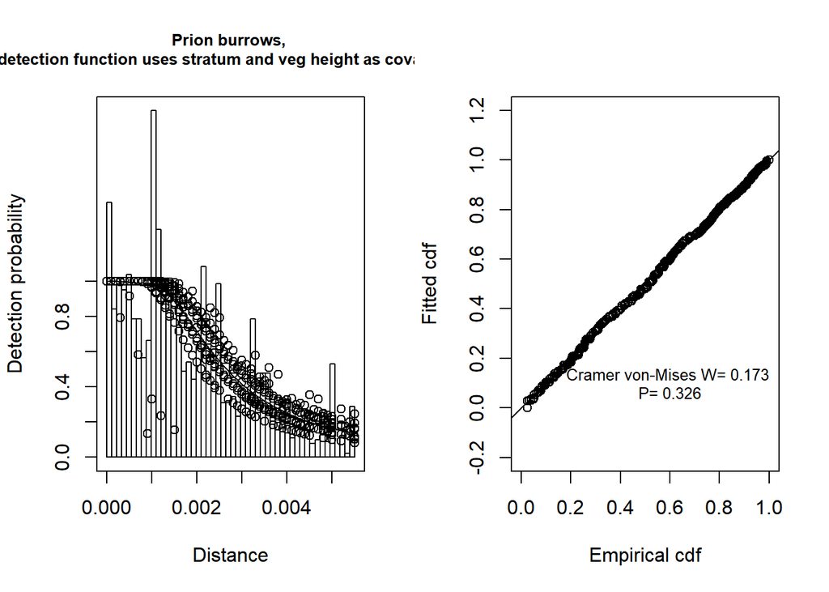

```r
par(mfrow=c(1,2))
plot(prion.strat.veg.hr, main="Prion burrows, \ndetection function uses stratum and veg height as covariates")
covar.fit <- ddf.gof(prion.strat.veg.hr$ddf)
message <- paste("Cramer von-Mises W=", round(covar.fit$dsgof$CvM$W,3),
                 "\nP=", round(covar.fit$dsgof$CvM$p,3))
text(0.6, 0.1, message, cex=0.8)
```

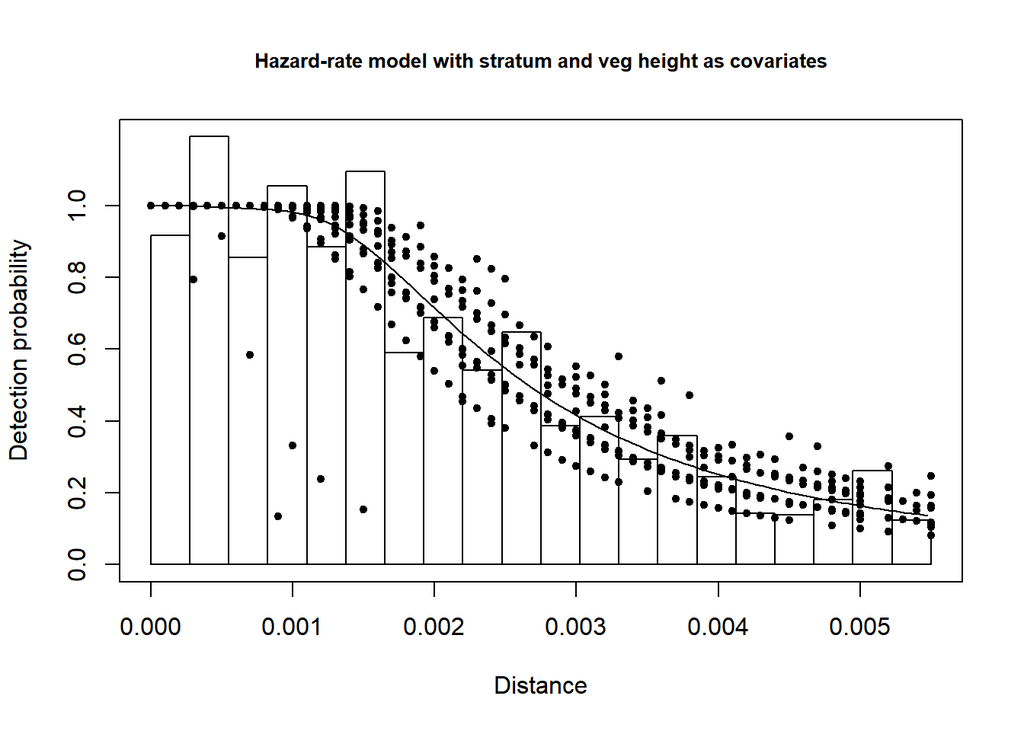

```r
# Plot simple model
plot(prion.strat.veg.hr, nc = 20, main = "Hazard-rate model with stratum and veg height as covariates",
     pch = 20)
```

```r
kable(prion.strat.veg.hr$dht$individuals$summary, format = "markdown")
```

| Region | Area | CoveredArea | Effort | n | ER | se.ER | cv.ER | mean.size | se.mean |
| --- | --- | --- | --- | --- | --- | --- | --- | --- | --- |
| 1 | 14.558758 | 0.2329896 | 21.180871 | 114 | 5.382215 | 1.7610015 | 0.3271890 | 1 | 0 |
| 2 | 21.142866 | 0.2769923 | 25.181114 | 634 | 25.177599 | 3.0521513 | 0.1212249 | 1 | 0 |
| 3 | 14.045445 | 0.1953059 | 17.755079 | 162 | 9.124150 | 2.0880171 | 0.2288451 | 1 | 0 |
| 4 | 7.156222 | 0.0481437 | 4.376703 | 30 | 6.854475 | 2.3376824 | 0.3410447 | 1 | 0 |
| 5 | 16.647776 | 0.3247644 | 29.524032 | 765 | 25.911095 | 2.7017202 | 0.1042689 | 1 | 0 |
| 6 | 16.124134 | 0.1358694 | 12.351761 | 57 | 4.614727 | 1.2838209 | 0.2782009 | 1 | 0 |
| 7 | 9.838014 | 0.1240275 | 11.275227 | 3 | 0.266070 | 0.1995903 | 0.7501421 | 1 | 0 |
| 8 | 23.896172 | 0.3909567 | 35.541521 | 718 | 20.201724 | 2.6056277 | 0.1289805 | 1 | 0 |
| Total | 123.409386 | 1.7290494 | 157.186308 | 2483 | 15.796541 | 1.0150649 | 0.0642587 | 1 | 0 |

```r
kable(prion.strat.veg.hr$dht$individuals$D,format="markdown")
```

| Label | Estimate | se | cv | lcl | ucl | df |
| --- | --- | --- | --- | --- | --- | --- |
| 1 | 955.5165 | 323.4831 | 0.3385427 | 500.28974 | 1824.966 | 540.5614 |
| 2 | 3964.7636 | 505.5425 | 0.1275089 | 3089.80978 | 5087.482 | 700.3408 |
| 3 | 1355.5932 | 321.8754 | 0.2374425 | 855.92643 | 2146.952 | 697.6897 |
| 4 | 1633.9642 | 777.6699 | 0.4759406 | 671.20977 | 3977.652 | 266.0739 |
| 5 | 4671.2394 | 522.5758 | 0.1118709 | 3752.73804 | 5814.549 | 741.8793 |
| 6 | 630.9691 | 190.1562 | 0.3013716 | 353.46485 | 1126.341 | 442.3623 |
| 7 | 224.2131 | 226.7841 | 1.0114666 | 43.15719 | 1164.847 | 788.4580 |
| 8 | 3122.4470 | 417.0009 | 0.1335494 | 2405.20761 | 4053.569 | 821.0101 |
| Total | 2376.0789 | 159.1944 | 0.0669988 | 2083.88873 | 2709.238 | 3331.4572 |

From the two resulting tables we multiply the total density estimate by the total area to give an island-wide estimate of burrows, and the lower and upper confidence limits to give 95% confidence:

= 293,198 (257,156-334,290)

For transect data truncating the furthest 5% of the data is recommended, but I’m not sure whether the stats then give an actual strip width. This is useful for segmenting the transect data to run density surface models, so it may be best just to truncate the data at 10 m which looks sensible from graphs of the data.

# Density Surface Modelling

Pages 1002-1003 of Miller et al. 2013 give an excellent summary of approaches to spatial modelling of distance sampling data. They advocate density surface modelling as a preferred option but it would be good to discuss this (and to potentially adopt alternative approaches for modelling Blue Petrel and Grey Petrel data).

I’ve had a preliminary but fairly weak effort at running some basic density surface models on our data. I don’t really understand the outputs at this point and am stuck at the point of needing to run predictions from the model.

The transects have been split into roughly 20 m square segments. I’ve calculate mean elevation and mean slope for each segment. We now have segment-level data, distance-data and linked distance-observations to segments.